# Analyse et gestion de la consommation énergétique

Ce notebook présente l’ensemble du pipeline d’analyse des données énergétiques simulées sur 30 jours pour deux compteurs, incluant le chargement et le nettoyage des données, l’analyse exploratoire et des séries temporelles, la détection d’anomalies, l’étude de la corrélation avec la température, la régression puissance–température, ainsi que l’optimisation de la gestion de la demande énergétique (DSM), le tout illustré par des visualisations finales.

## 1️⃣ Chargement et nettoyage des données (01_data_loading_cleaning.py)

### 1.1 Chargement et conversion

```python
import numpy as np
import pandas as pd
import matplotlib.pyplot as plt
import seaborn as sns

from scipy.stats import zscore, norm, skew, kurtosis, shapiro
from statsmodels.graphics.tsaplots import plot_acf
from sklearn.metrics import mean_absolute_error, mean_squared_error
from sklearn.ensemble import IsolationForest, RandomForestRegressor


# Charger le fichier CSV
df = pd.read_csv('../data/energy_readings_month.csv', sep=";", encoding="utf-8")

# Enlever les espaces éventuels
df.columns = df.columns.str.strip()

# Convertir power_kw en numérique (les virgules en VS Code sont des points)
df["power_kw"] = (df["power_kw"].astype(str).str.replace(',', '.'))
df["power_kw"] = pd.to_numeric(df["power_kw"], errors="coerce")

# Convertir timestamp, pd.to_datetime() convertit cette colonne en objet datetime que Python peut comprendre comme une date/heure
df["timestamp"] = pd.to_datetime(df["timestamp"])

# Test d'affichage des 2 premières lignes
print("Test d'affichage de 2 premières lignes de DataFrame :")
df.head(2)
```

```
Test d'affichage de 2 premières lignes de DataFrame :
```

|  | meter_id | timestamp | power_kw |
| --- | --- | --- | --- |
| 0 | 1 | 2026-01-01 00:00:00 | 116.59 |
| 1 | 1 | 2026-01-01 01:00:00 | 108.72 |

### 1.2 Nettoyage et structuration des données

```python
print("Contrôle de qualité des données :")

# Vérifier des valeurs manquantes (NaN)
print("Nombre total de valeurs manquantes dans le DataFrame :", df.isna().sum().sum())

# Supprimer les valeurs NaN dans les colonnes timestamp ou power_kw si elles existent (si valeure nulle toute la ligne sera supprimée)
df = df.dropna(subset=["timestamp", "power_kw"])

# Remplir les NaN par la dernière valeur connue
# df = df.fillna(method='ffill')

# Vérifier les doublons par colonnes spécifiques (meter_id + timestamp)
doublons = df[df.duplicated(subset=["meter_id","timestamp"], keep=False)]
print(f"Nombre total de doublons détectés dans le DataFrame : {len(doublons)}")

# supprimer des doublons
df = df.drop_duplicates(subset=["meter_id","timestamp"], keep='first')

# Vérifier les valeurs aberrantes (les puissances négatives seront supprimées)
valeurs_aberrantes = df[df["power_kw"] < 0]
print(f"Nombre total de valeurs aberrantes détectées dans le DataFrame : {len(valeurs_aberrantes)}")

# supprimer valeurs aberrantes
df = df[df["power_kw"] >= 0]

# Trier chronologiquement selon "meter_id", "timestamp"
df = df.sort_values(["meter_id", "timestamp"], ascending=[True, True])

# réinitialiser l’index du DataFrame après un tri, un filtre ou une suppression de lignes
df = df.reset_index(drop=True)
```

```
Contrôle de qualité des données :
Nombre total de valeurs manquantes dans le DataFrame : 0
Nombre total de doublons détectés dans le DataFrame : 0
Nombre total de valeurs aberrantes détectées dans le DataFrame : 0
```

### 1.3 Création de nouvelles colonnes

```python
# Créer une nouvelle colonne heure dans le DataFrame df (de 0 à 23)
df["heure"] = df["timestamp"].dt.hour

# Créer une nouvelle colonne jour (de 1 à 30)
df["jour"] = df["timestamp"].dt.day

# Créer une nouvelle colonne jour_semaine (0=lundi, 1=mardi, ... 6=dimanche)
df["jour_semaine"] = df["timestamp"].dt.weekday
df["type_jour"] = np.where(df["jour_semaine"] < 5, "semaine", "weekend") # classer selon type_jour : semaine ou weekend

# Créer une nouvelle colonne num_semaine (1=première semaine, 2=deuxième semaine, ... )
df["num_semaine"] = df["timestamp"].dt.isocalendar().week

# Créer une nouvelle colonne week_end (True si weekend si non False)
df["week_end"] = df["jour_semaine"].isin([5,6])

# Créer une nouvelle colonne energie_h (kwh), multiplie chaque valeur de power_kw par 1 heure (puisque c'est des enregistrements horaires)
df["energie_kwh"] = df["power_kw"] * 1

# Accumulation de l'energie par heure (on peut faire pareil par jour, semaine, ...)
df["energy_cum_kwh"] = (df.groupby("meter_id")["energie_kwh"].cumsum())

# Séparer les données selon meter_id (si on veut le faire bien-sur)
df1 = df[df["meter_id"] == 1]
df2 = df[df["meter_id"] == 2]
```

## 2️⃣ Analyse exploratoire (02_exploratory_analysis.py)

### 2.1 Puissances horaires sur tout le mois pour chaque compteur

Les courbes de puissances horaires permettent de visualiser les cycles journaliers, la régularité du fonctionnement, les variations ponctuelles et les anomalies.

- **Compteur 1 :** Présente un cycle journalier typique : faible consommation la nuit, montée la journée et baisse le soir, avec réduction le week-end (~35%). Les pics artificiels des jours 12 et 22 (09h–11h, +80 kW) permettent de tester la détection d’anomalies.
- **Compteur 2 :** Reste quasi constant autour de ~300 kW sur 30 jours, avec faible variabilité (±10 kW). Les pics artificiels des jours 12 et 22 (+30 kW) sont visibles mais peu marqués.

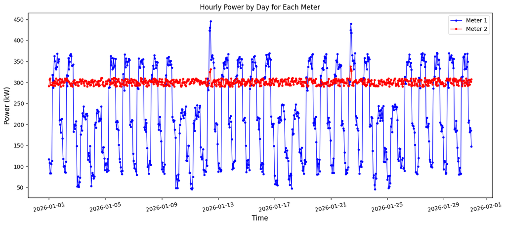

```python
plt.figure(figsize=(15,6))
"""
Tracer la puissance brute par jour pour chaque compteur
"""
colors = ['blue','red']
for i, meter in enumerate(df['meter_id'].unique()):
    df_sub = df[df['meter_id'] == meter]

    plt.plot(
        df_sub["timestamp"],
        df_sub["power_kw"],
        linestyle='-',
        linewidth=1,
        color=colors[i],
        marker='o',
        markersize=3,
        label=f"Meter {meter}"
    )

plt.xlabel("Time", fontsize=12)
plt.ylabel("Power (kW)", fontsize=12)
plt.title("Hourly Power by Day for Each Meter", fontsize=12)
plt.xticks(rotation=10)
plt.legend()
plt.show()
```

### 2.2 Visualisation des distributions des deux compteurs

Les histogrammes montrent la répartition des puissances horaires pour chaque compteur.

- **Compteur 1 :** Ce n’est pas une distribution gaussienne, mais une distribution clairement multimodale, indiquant la présence d’au moins trois régimes de fonctionnement distincts. Un régime basse charge (~80–120 kW), un régime intermédiaire (~190–230 kW) et un régime haute charge (~320–360 kW), ainsi que quelques valeurs extrêmes au-delà de 420 kW. Cela montre que le compteur ne fonctionne pas selon un mode continu et variable, mais plutôt des modes d’exploitation distincts (occupation, demi-charge, pleine charge).
- **Compteur 2 :** Distribution quasi unimodale, avec un pic autour de ~300 kW et une faible dispersion. La moyenne est proche de la médiane et la gaussienne s’ajuste relativement bien, mais quelques pointes rares (330–340 kW) ont été introduites pour simuler des anomalies. Les statistiques confirment ce comportement : skewness = 0.73 (légère asymétrie droite), kurtosis = 2.6 (pic marqué, queues plus épaisses), et le test de Shapiro (p ≪ 0.05) rejette l’hypothèse de normalité. Ces valeurs montrent que, malgré une charge quasi constante et un fonctionnement stable, des extrêmes ponctuels existent.

```
Les stats pour le compteur 1 :
```

| Skewness | Kurtosis | p-value |
| --- | --- | --- |
| 0.06 | -1.36 | 4.63e-19 |

```
Les stats pour le compteur 2 :
```

| Skewness | Kurtosis | p-value |
| --- | --- | --- |
| 0.73 | 2.60 | 2.77e-17 |

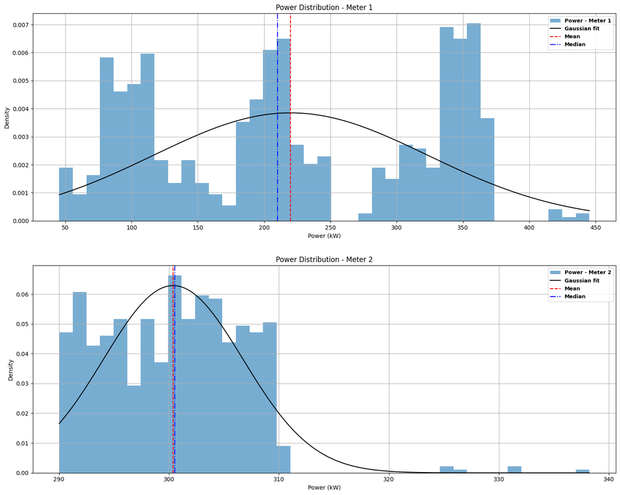

```python
def plot_distribution_subplots_indep(df, meter_ids=[1,2]):
    """
    Fonction de visualisation combinée : histogramme, ajustement gaussien, moyenne et médiane sur un même graphique
    """
    fig, axes = plt.subplots(len(meter_ids), 1, figsize=(15, 6*len(meter_ids)), sharex=False)

    for i, meter_id in enumerate(meter_ids):
        ax = axes[i]
        data = df[df["meter_id"] == meter_id]["power_kw"]

        mean_val = data.mean()
        median_val = data.median()
        std_val = data.std()

        # Bins spécifiques à ce compteur
        bins = np.linspace(data.min(), data.max(), 40)

        # Histogramme normalisé
        ax.hist(data, bins=bins, density=True, alpha=0.6, label=f"Power - Meter {meter_id}")

        # Courbe gaussienne
        x = np.linspace(data.min(), data.max(), 1000)
        gaussian = norm.pdf(x, mean_val, std_val)
        ax.plot(x, gaussian, label="Gaussian fit", color="black")

        # Moyenne et médiane
        ax.axvline(mean_val, linestyle='--', color="red", label="Mean")
        ax.axvline(median_val, linestyle='-.', color="blue", label="Median")

        # Calculer et afficher les stats dans un tableau horizontal
        df_results = pd.DataFrame([[skew(data), kurtosis(data), shapiro(data)[1]]], columns=["Skewness", "Kurtosis", "p-value"])
        print(f"\nLes stats pour le compteur {meter_id} :")
        display(df_results.style.format({"Skewness": "{:.2f}", "Kurtosis": "{:.2f}", "p-value": "{:.2e}"}).hide(axis="index"))

        ax.set_xlabel("Power (kW)")
        ax.set_ylabel("Density")
        ax.set_title(f"Power Distribution - Meter {meter_id}")
        ax.legend(prop={'weight': 'bold', 'size': 9})
        ax.grid(True)

    plt.tight_layout(h_pad=3)
    plt.show()

plot_distribution_subplots_indep(df, meter_ids=[1,2])
```

### 2.3 Heatmap de puissance par heure et par jour pour chaque compteur

La Heatmap affiche chaque jour du mois en ligne et chaque heure en colonne, avec la couleur représentant la puissance mesurée. Cela permet de visualiser facilement les motifs journaliers (pics et creux), la régularité du fonctionnement, les anomalies ponctuelles et les différences entre jours de semaine et week-end, etc.

- **Compteur 1 :** La Heatmap montre un cycle journalier marqué : faible consommation la nuit (23h–05h), montée le matin (06h–08h), plateau en journée (09h–17h) et baisse le soir (18h–22h). Les week-ends sont moins chargés (03/04, 10/11, 17/18, 24/25, ~35%). Les pics artificiels des jours 12 et 22 apparaissent localement (09h–11h). Les variations régulières sont visibles grâce aux couleurs, et la carte montre que les valeurs minimales se situent la nuit et les valeurs maximales en pleine journée.
- **Compteur 2 :** La Heatmap est quasi uniforme, reflétant une charge stable autour de ~300 kW avec de faibles fluctuations. Les pics des jours 12 et 22 (09h–11h, +30 kW) sont visibles mais peu prononcés. Ce compteur fonctionne à régime quasi constant, avec très peu de cycles journaliers ou hebdomadaires. Les anomalies ponctuelles se détectent grâce aux variations de couleur, et les valeurs minimales et maximales peuvent apparaître à n’importe quel moment de la journée.

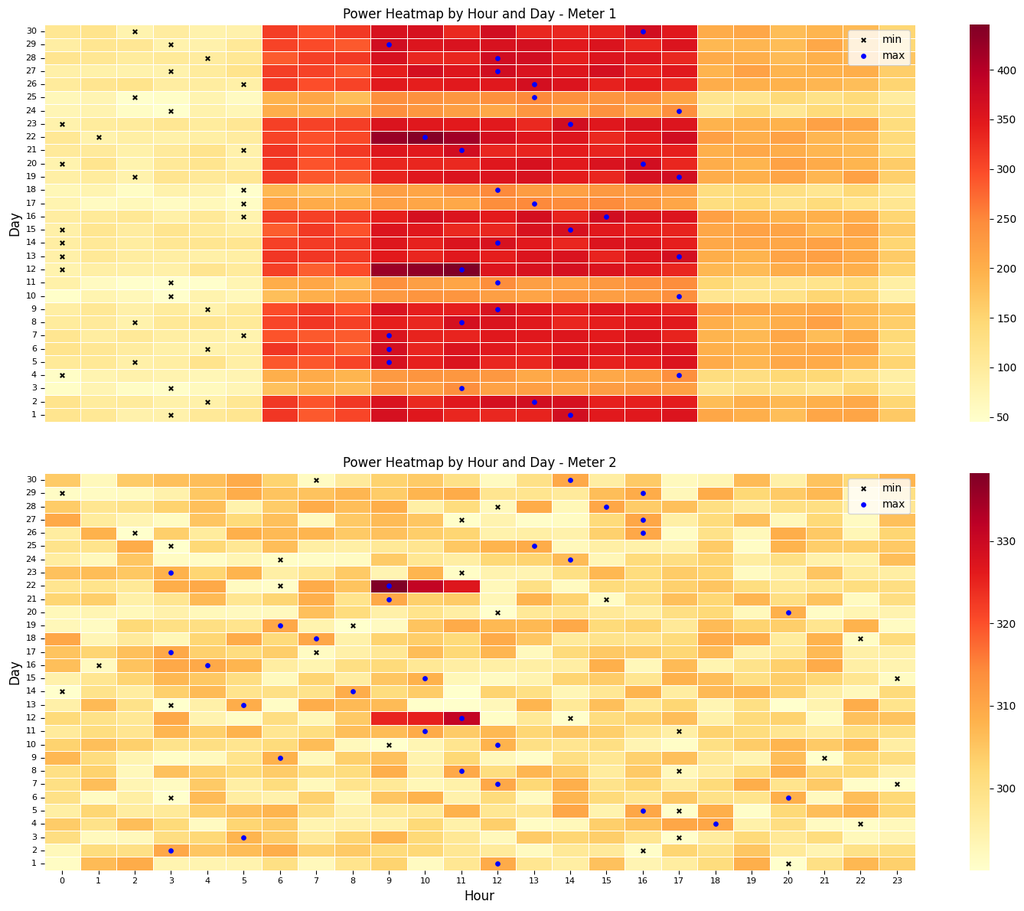

```python
def analyse_type_jour_subplots(df_list, type_jour_label_list):
    """
    Affiche en subplots les heatmaps pour plusieurs DataFrames/compteurs.

    df_list : liste de DataFrames (un par compteur)
    type_jour_label_list : liste de labels de type_jour à filtrer (ex: ['semaine','weekend'])
    """
    n_meters = len(df_list)
    fig, axes = plt.subplots(n_meters, 1, figsize=(15, 6*n_meters), sharex=True)

    # s'assurer que axes est toujours itérable
    if n_meters == 1:
        axes = [axes]

    for i, df in enumerate(df_list):
        ax = axes[i]

        # sélection selon type_jour : si liste
        if isinstance(type_jour_label_list, list):
            df_type = df[df["type_jour"].isin(type_jour_label_list)].copy()
            label_str = ", ".join([str(x).upper() for x in type_jour_label_list])
        else: # si pas une liste
            df_type = df[df["type_jour"] == type_jour_label_list].copy()
            label_str = str(type_jour_label_list).upper()

        if df_type.empty: #! si aucune ligne ne correspond à la sélection
            print(f"Aucune donnée pour {label_str}")
            continue

        # données Heatmap
        heat = df_type.pivot_table(index="jour", columns="heure", values="power_kw", aggfunc="mean")

        # Min et max par jour
        min_points = df_type.loc[df_type.groupby("jour")["power_kw"].idxmin()]
        max_points = df_type.loc[df_type.groupby("jour")["power_kw"].idxmax()]

        # créer un matrice booléenne de la même taille que données Heatmap
        min_matrix = pd.DataFrame(False, index=heat.index, columns=heat.columns)
        max_matrix = pd.DataFrame(False, index=heat.index, columns=heat.columns)

        for _, row in min_points.iterrows():
            j, h = row["jour"], row["heure"]
            if j in heat.index and h in heat.columns:
                min_matrix.loc[j, h] = True

        for _, row in max_points.iterrows():
            j, h = row["jour"], row["heure"]
            if j in heat.index and h in heat.columns:
                max_matrix.loc[j, h] = True

        # Heatmap
        sns.heatmap(heat, cmap='YlOrRd', linewidths=0.5, annot=False, ax=ax)
        # cacher X pour le premier subplot
        if i == 0: ax.xaxis.set_visible(False)

        ax.set_xlabel("Hour", fontsize=12)
        ax.set_ylabel("Day", fontsize=12)
        ax.set_xticks(np.arange(len(heat.columns))+0.5)
        ax.set_xticklabels(heat.columns, fontsize=8)
        ax.set_yticks(np.arange(len(heat.index))+0.5)
        ax.set_yticklabels(heat.index, fontsize=8)
        ax.invert_yaxis()
        ax.set_title(f"Power Heatmap by Hour and Day - Meter {df_type['meter_id'].iloc[0]}", fontsize=12)
        ax.tick_params(axis='y', rotation=0)


        # Min et max
        jours_min, heures_min = np.where(min_matrix)
        jours_max, heures_max = np.where(max_matrix)
        ax.scatter(heures_min+0.5, jours_min+0.5, color='black', marker='x', s=15, label='min')
        ax.scatter(heures_max+0.5, jours_max+0.5, color='blue', marker='o', s=15, label='max')
        ax.legend()

    plt.tight_layout(h_pad=3)
    plt.show()

analyse_type_jour_subplots([df1, df2], ['semaine','weekend'])
```

## 3️⃣ Analyse des séries temporelles (03_time_series_analysis.py)

### 3.1 Analyse de l’autocorrélation des séries temporelles :

- **Compteur 1 :** Forme sinusoïdale, révélant un cycle journalier régulier (24h). La puissance à une heure donnée ressemble beaucoup à celle de la même heure les jours précédents. Ce qui correspond à un bâtiment tertiaire ou activité planifiée, avec un comportement structuré et périodique. Pour ce compteur, il est pertinent d’analyser le profil journalier et hebdomadaire, le facteur de charge, et les tendances globales via rolling mean.
- **Compteur 2 :** Autocorrélation très faible, toutes les barres proches de 0, indiquant que la puissance actuelle ne dépend pas du passé. La consommation est aléatoire, bruitée, sans cycle identifiable. Pour ce compteur, il est conseillé d’étudier le rolling mean, le coefficient de variation (CV), le Z-robuste et l’Indice d’Instabilité Énergétique (IIE) pour détecter les instabilités ou anomalies ponctuelles.

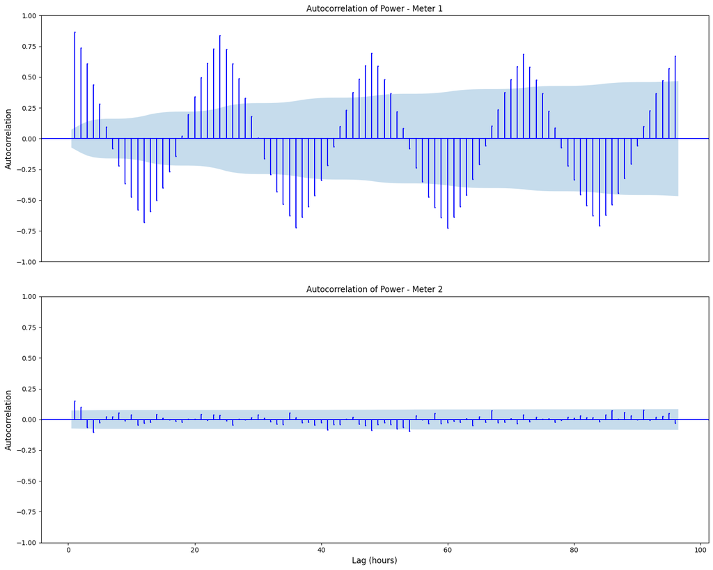

```python
def plot_acf_meters_subplots(df_list, lags=719):
    """
    Trace l'autocorrélation de plusieurs compteurs en subplots.
    Ici calcul pour toute la période (720 heures, lags = 719)
    df_list : liste de tuples (DataFrame, nom_compteur)
    """
    n_meters = len(df_list)
    fig, axes = plt.subplots(n_meters, 1, figsize=(15, 6*n_meters), sharex=True)

    # s'assurer que axes est itérable
    if n_meters == 1:
        axes = [axes]

    for i, (df, meter_name) in enumerate(df_list):
        ax = axes[i]
        plot_acf(df["power_kw"].dropna(), lags=lags, zero=False, color='blue', marker='o', markersize=1,
                 vlines_kwargs={'color': 'blue'}, ax=ax)

        if i == 0: ax.xaxis.set_visible(False)

        ax.set_title(f"Autocorrelation of Power - {meter_name}", fontsize=12)
        ax.set_xlabel("Lag (hours)", fontsize=12)
        ax.set_ylabel("Autocorrelation", fontsize=12)

    plt.tight_layout(h_pad=3)
    plt.show()

# Exemple tracé en subplots pour les deux compteurs pour 4 jours
plot_acf_meters_subplots([(df1, "Meter 1"), (df2, "Meter 2")], lags=96)
```

### 3.2 Analyse de la stabilité et des fluctuations des séries temporelles :

#### 3.2.1 Puissance et rolling mean

**Rolling mean** ou **moyenne glissante** : Permet de lisser les données temporelles afin de mieux visualiser les tendances. Elle calcule la moyenne sur une fenêtre glissante de plusieurs heures. Une fenêtre courte (**3 h**) met en évidence les variations locales, tandis qu’une fenêtre plus longue (**6 h**, **12 h**) lisse le signal et fait ressortir les tendances globales en filtrant le bruit.

##### Analyse des courbes :

- Plus la fenêtre est grande, plus le signal est lissé et certaines fluctuations locales disparaissent. Cela facilite la lecture des tendances globales, mais peut masquer des instabilités ponctuelles.
- **Compteur 1 :** la moyenne glissante fait ressortir les cycles journaliers et les pics de charge, malgré le lissage, on voit bien les transitions jour/nuit et les variations importantes.
- **Compteur 2 :** la moyenne glissante reste presque constante, le signal est très lisse, seules de fluctuations importantes apparaissent aux rares pics, le compteur est donc globalement stable.

##### Résumé :

- **Compteur 1 (structuré)** → utile pour analyser tendances et cycles, variations importantes visibles même après lissage.
- **Compteur 2 (stable)** → montre très peu de variabilité, le rolling mean confirme la stabilité du signal et l’absence de cycles marqués.

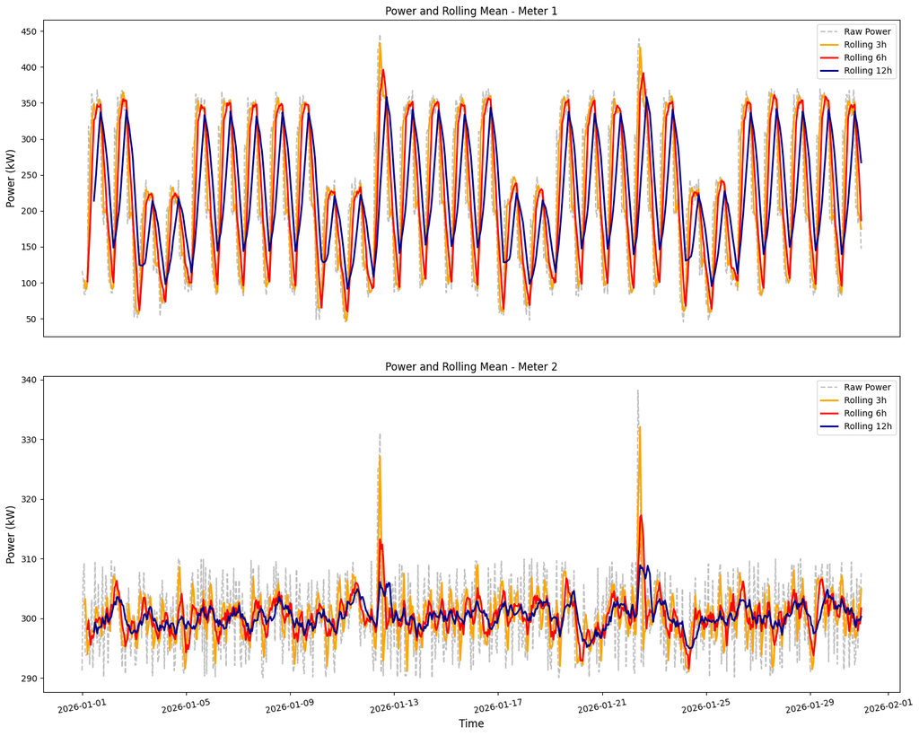

```python
def tracer_Rolling_subplots(df_list, fenetres=[3,6,12], colors=["orange","red","darkblue"]):
    """
    Trace la puissance brute et les moyennes glissantes pour plusieurs compteurs en subplots.
    df_list : liste de tuples (DataFrame, meter_id)
    """
    n_meters = len(df_list)
    fig, axes = plt.subplots(n_meters, 1, figsize=(15, 6*n_meters), sharex=True)

    if n_meters == 1:
        axes = [axes]

    for i, (df, meter_id) in enumerate(df_list):
        ax = axes[i]
        df_meter = df[df["meter_id"] == meter_id].copy()

        # Puissance brute
        ax.plot(df_meter["timestamp"], df_meter["power_kw"], linestyle='--', color='gray', alpha=0.5, label="Raw Power")

        # Tracer Rolling
        for j, w in enumerate(fenetres):
            df_meter[f"mw_{w}h"] = df_meter["power_kw"].rolling(w).mean()
            ax.plot(df_meter["timestamp"], df_meter[f"mw_{w}h"], label=f"Rolling {w}h", color=colors[j], linewidth=2)

        if i == 0: ax.xaxis.set_visible(False)
        ax.set_xlabel("Time", fontsize=12)
        ax.set_ylabel("Power (kW)", fontsize=12)
        ax.set_title(f"Power and Rolling Mean - Meter {meter_id}", fontsize=12)
        ax.legend()
        ax.tick_params(axis='x', rotation=10)

    plt.tight_layout(h_pad=3)
    plt.show()

    # Retourner les DataFrames pour chaque compteur
    return [df[df["meter_id"] == meter_id].copy() for _, meter_id in df_list]

# Tracé en subplots pour les deux compteurs
df1_meter, df2_meter = tracer_Rolling_subplots([(df, 1), (df, 2)])
```

#### 3.2.2 Coefficient de Variation (CV)

**Coefficient de variation (CV)** : mesure la **variabilité relative** (écart-type rapporté à la moyenne), utile pour comparer des signaux de niveaux différents. Le **CV** est essentiel pour le calcul de l’**Indice d’Instabilité Énergétique** (**IIE**) afin d’identifier les fluctuations et anomalies ponctuelles dans les séries temporelles.

- **Compteur 1 :**
  - CV rolling élevé, atteint jusqu’à 0,8 aux transitions jour/nuit et pics de charge (ce qui signifie que l’écart-type est presque égal à la puissance moyenne).
  - Forte variabilité, cycles journaliers marqués.
  - Comportement très dynamique non stable.
- **Compteur 2 :**
  - CV rolling reste généralement très faible (< 0,035) et, même dans les cas extrêmes, l’écart-type ne dépasse pas 7 % de la puissance moyenne.
  - Fluctuations ponctuelles dues au bruit simulé.
  - Comportement globalement stable.

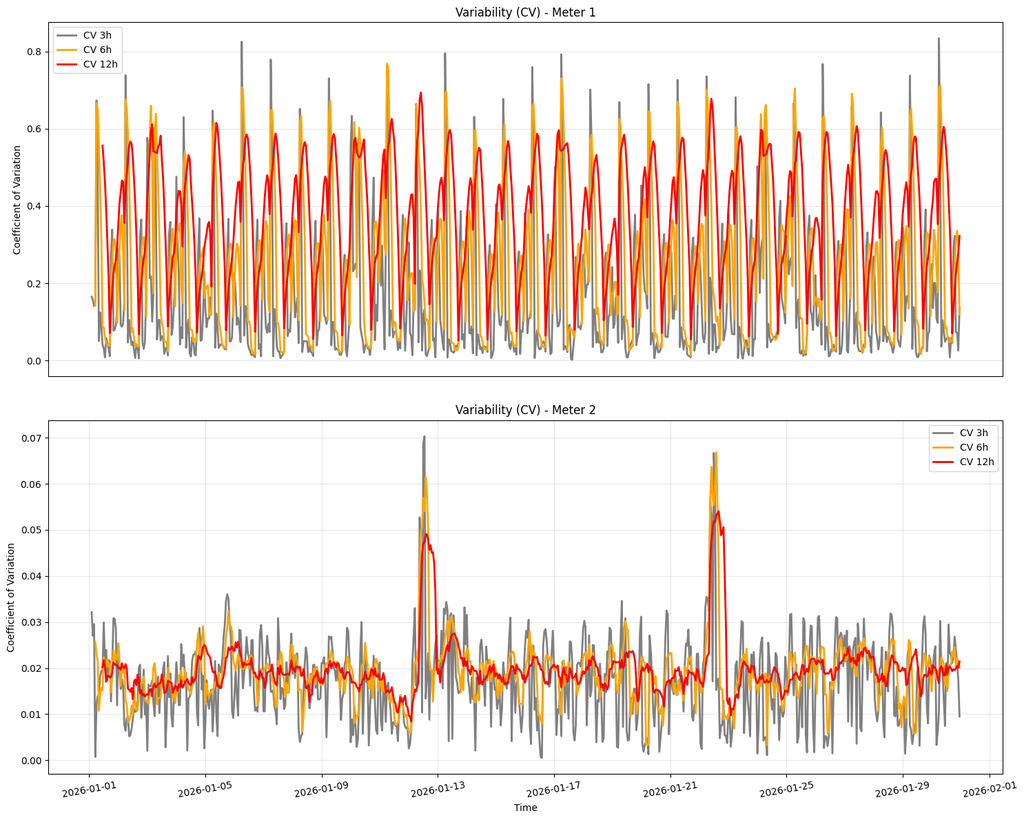

```python
def tracer_CV_subplots(df_list, fenetres=[3,6,12], colors=["gray","orange","red"]):
    """
    Trace le coefficient de variation (CV) pour plusieurs compteurs en subplots.
    df_list : liste de tuples (DataFrame, meter_id)
    """
    n_meters = len(df_list)
    fig, axes = plt.subplots(n_meters, 1, figsize=(15, 6*n_meters), sharex=True)

    if n_meters == 1:
        axes = [axes]

    for i, (df, meter_id) in enumerate(df_list):
        ax = axes[i]
        df_meter = df[df["meter_id"] == meter_id].copy()

        for j, w in enumerate(fenetres):
            # Moyenne glissante
            df_meter[f"mw_{w}h"] = df_meter["power_kw"].rolling(w).mean()
            # Ecart-type glissant
            df_meter[f"std_{w}h"] = df_meter["power_kw"].rolling(w).std()
            # Coefficient de variation
            df_meter[f"cv_{w}h"] = df_meter[f"std_{w}h"] / df_meter[f"mw_{w}h"]

            # Tracer du CV
            ax.plot(df_meter["timestamp"], df_meter[f"cv_{w}h"],
                    label=f"CV {w}h", color=colors[j], linewidth=2)


        if i == 0: ax.xaxis.set_visible(False)
        ax.set_xlabel("Time")
        ax.set_ylabel("Coefficient of Variation")
        ax.set_title(f"Variability (CV) - Meter {meter_id}")
        ax.legend()
        ax.grid(alpha=0.3)
        ax.tick_params(axis='x', rotation=10)

    plt.tight_layout(h_pad=3)
    plt.show()

    return [df[df["meter_id"] == meter_id].copy() for _, meter_id in df_list]

df1_cv, df2_cv = tracer_CV_subplots([(df, 1), (df, 2)])
```

## 4️⃣ Détection d'anomalies (04_anomaly_detection.py)

### 4.1 Analyse des anomalies avec des méthodes statistiques

#### 4.1.1 Z-score (score standardisé)

Le Z-score mesure l’écart d’une valeur de puissance par rapport à la moyenne, normalisé par l’écart-type. Il permet de détecter les points anormaux dans les séries temporelles de puissance. Il est défini par : $$ Z_{\mathrm{score}} = \frac{x - \mu}{\sigma} $$

avec 𝑥 : valeur observée (ici c'est la puissance), 𝜇 : moyenne et 𝜎 : écart-type

##### Observations :

- **Compteur 1 :** 3 anomalies détectées (jours 12 et 22), correspondant aux pics artificiels malgré la forte variabilité quotidienne.
- **Compteur 2 :** 6 anomalies détectées (jours 12 et 22), facilement identifiables grâce à la puissance quasi constante.

##### Conclusion : Le Z-score identifie clairement les pics artificiels pour les deux compteurs, même si la variabilité naturelle diffère.

*À noter que le seuil que j'ai choisi ici est de 2 pour filtrer les anomalies légères, mais peut être porté à 3 pour éliminer les anomalies fortes et extrêmes, qui sont généralement retirées de l’analyse.*

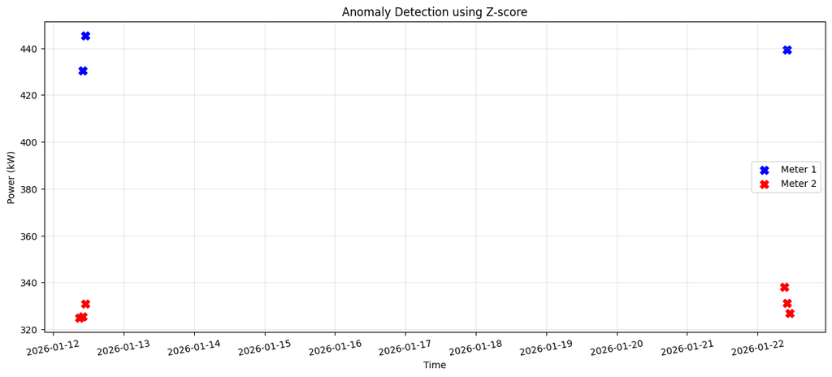

```python
# Détection des anaomalies par Z-score (Prédéfini déjà sur Python)

df["z_score"] = df.groupby("meter_id")["power_kw"].transform(lambda x: zscore(x))
# Une valeur est considérée comme une anomalie si l’absolu du z-score > 2
df["state_z_score"] = np.where(df["z_score"].abs() > 2, "anomaly", "normal")

# Filtrer anomalies
df_anom = df[df["state_z_score"] == "anomaly"]

plt.figure(figsize=(15,6))

# Compteur 1
plt.scatter(df_anom[df_anom["meter_id"] == 1]["timestamp"], df_anom[df_anom["meter_id"] == 1]["power_kw"], color="blue", marker="X", s=80, label="Meter 1")
# Compteur 2
plt.scatter(df_anom[df_anom["meter_id"] == 2]["timestamp"], df_anom[df_anom["meter_id"] == 2]["power_kw"], color="red", marker="X", s=80, label="Meter 2")

plt.title("Anomaly Detection using Z-score")
plt.xlabel("Time")
plt.ylabel("Power (kW)")

# Afficher toutes les dates de df_anom sur l'axe x
dates = pd.date_range(df_anom["timestamp"].min().normalize(), df_anom["timestamp"].max().normalize(), freq='D')
plt.xticks(dates, rotation=10)

plt.legend()
plt.grid(alpha=0.3)
plt.show()
```

#### 4.1.2 Z-robuste (ou Z-score robuste)

Le Z‑robuste est une version du Z‑score classique qui évalue l’écart d’un point à la tendance centrale en utilisant des statistiques moins sensibles aux valeurs extrêmes. Il est défini par : $$ Z_{\mathrm{robuste}} = \frac{x - \mathrm{médiane}(X)}{k \cdot \mathrm{MAD}} $$ $$ \quad\text{avec}\quad \mathrm{MAD} = \mathrm{médiane}(|X - \mathrm{médiane}(X)|) \quad\text{et $k$ ≈ 1.4826 le facteur de normalisation pour rendre MAD comparable à l’écart-type classique}\quad $$ Le Z-robuste est moins sensible aux outliers qu’un Z-score classique (puisque il se base sur la mesure centrale pas sur la mesure de dispersion), il est idéal pour détecter des anomalies ponctuelles dans des séries temporelles présentant des fluctuations naturelles importantes.

##### Observations :

- **Compteur 1 :** aucune anomalie détectée par le Z-robuste.
- **Compteur 2 :** toutes les 6 anomalies simulées sont correctement détectées (3 le jour 12, 3 le jour 22) tout comme avec Z-score.

##### Interprétation :

- Le Z-robuste, basé sur la médiane et le MAD, est moins sensible aux valeurs extrêmes ponctuelles que le Z-score classique.
- Pour le compteur 1, dont la consommation est très dynamique mais structurée, les pics ponctuels ne suffisent pas à dépasser le seuil du Z-robuste.
- Le compteur 2, avec une puissance relativement constante, montre des écarts ponctuels facilement identifiables par le Z-robuste.

##### Conclusion :

- Le Z‑robuste ignore les variations normales des signaux dynamiques et ne met en évidence que les écarts significatifs, protégeant ainsi le centre de la distribution contre l’influence des valeurs extrêmes qui pourraient fausser les statistiques globales.
- Les résultats confirment que le compteur 1 est non stable mais structuré, tandis que le compteur 2 est stable et sensible aux anomalies ponctuelles.

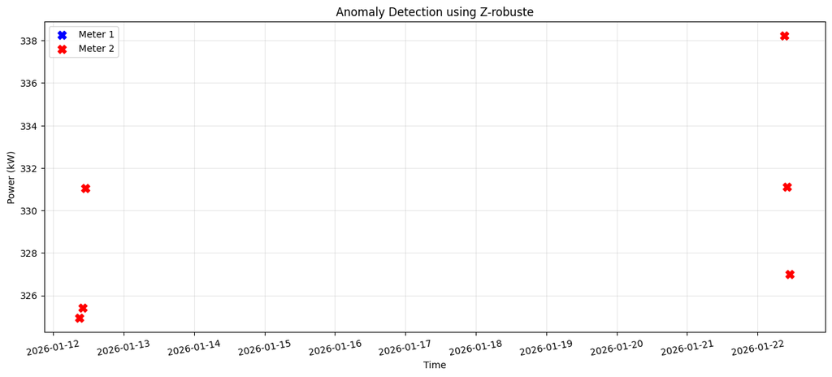

```python
# Détection des anaomalies par Z-robuste

df["median"] = df.groupby("meter_id")["power_kw"].transform("median")
df["mad"] = df.groupby("meter_id")["power_kw"].transform(lambda x: np.median(np.abs(x - np.median(x))))

# Normalisation avec 1.4826 pour rendre comparable au Z-score (si on suppose une distribution normale)
df["z_robust"] = (df["power_kw"] - df["median"]) / (1.4826 * df["mad"])

# Détection d'anomalies avec seuil = 2 (comme dans Z-score)
df["state_z_robust"] = np.where(df["z_robust"].abs() > 2, "anomaly", "normal")

# Filtrer anomalies
df_anom = df[df["state_z_robust"] == "anomaly"]

plt.figure(figsize=(15,6))
plt.scatter(df_anom[df_anom["meter_id"] == 1]["timestamp"], df_anom[df_anom["meter_id"] == 1]["power_kw"], color="blue", marker="X", s=80, label="Meter 1")
plt.scatter(df_anom[df_anom["meter_id"] == 2]["timestamp"], df_anom[df_anom["meter_id"] == 2]["power_kw"], color="red", marker="X", s=80, label="Meter 2")

plt.title("Anomaly Detection using Z-robuste")
plt.xlabel("Time")
plt.ylabel("Power (kW)")

dates = pd.date_range(df_anom["timestamp"].min().normalize(), df_anom["timestamp"].max().normalize(), freq='D')
plt.xticks(dates, rotation=10)

plt.legend()
plt.grid(alpha=0.3)
plt.show()
```

#### 4.1.3 Indice d’Instabilité Énergétique (IIE) avec Fenêtre Glissante (Rolling Window)

L’IIE est un indicateur permettant de quantifier le niveau d’instabilité d’un signal de puissance en se basant sur la variabilité relative (coefficient de variation CV) et une normalisation robuste. Il est défini comme un Z-robuste du coefficient de variation : $$ IIE = \frac{CV - \mathrm{median}(CV)}{1.4826 \cdot \mathrm{MAD}(CV)} $$

L’IIE mesure à quel point la variabilité d’un signal est anormalement élevée par rapport à son comportement habituel.  
IIE ≈ 0 → comportement normal, IIE > 2 → instabilité modérée, IIE > 3 → instabilité forte (anomalie probable).

##### Interprétation de l’Indice d’Instabilité Énergétique (IIE)

- **Régime normal :** IIE ≈ 0  
  (autour de la médiane, faible écart par rapport à la variabilité typique)  
  Interprétation physique : fluctuations faibles, fonctionnement stable, aucune intervention nécessaire.
- **Instabilité modérée :** IIE > 2  
  (écart significatif mais non critique)  
  Interprétation physique : fluctuations locales supérieures à la normale, oscillations détectables mais non critiques.  
  Peut signaler : variabilité du process ou changements de charge prévisibles (ex : pics en journée).
- **Instabilité forte :** IIE > 3  
  (écart très significatif par rapport à la variabilité normale)  
  Interprétation physique : oscillations importantes ou comportement incohérent.  
  Peut correspondre à : anomalies du système (défauts mécaniques/électriques) ou comportement anormal du site.

##### Observations

- **Compteur 1 :**
  - Rolling 3h : nombreux points d'instabilité modérée (2 < IIE ≤ 3) et forte (IIE > 3) sur toute la période, reflétant les fluctuations locales sur des cycles courts.
  - Rolling 6h : quelques anomalies modérées, beaucoup moins nombreuses, le lissage atténue les variations ponctuelles.
  - Rolling 9h et 12h : aucune anomalie détectée, le signal lissé montre la stabilité du système.
- **Compteur 2 :**
  - Anomalies concentrées sur les jours 12 et 22, correspondant aux pics artificiels.
  - Très peu de points d'instabilité en dehors de ces jours, fonctionnement quasi constant.
  - Les anomalies se multiplient légèrement avec les grandes fenêtres glissantes, car le lissage accumule les variations autour des pics, ce qui augmente également la valeur de l’IIE sur ces périodes.

##### Conclusion

Le compteur 1 présente un comportement structuré avec des fluctuations visibles uniquement sur fenêtres courtes, tandis que le compteur 2 reste globalement stable avec des anomalies ponctuelles bien localisées, visibles surtout avec des fenêtres longues. L’analyse de l’IIE sur différentes fenêtres glissantes permet ainsi de distinguer les signaux structurés des signaux quasi constants et de détecter efficacement les instabilités locales.

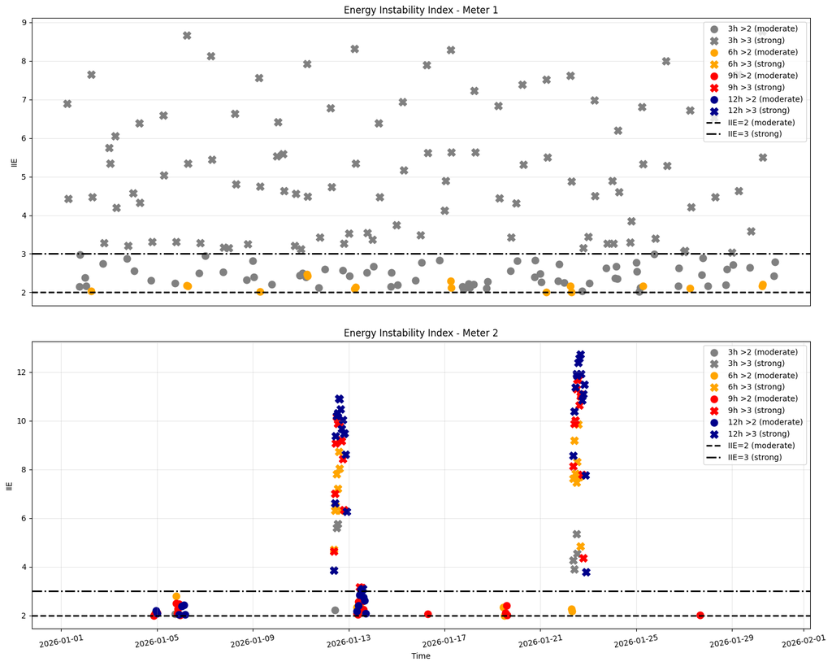

```python
def plot_IIE_points_subplots(df_list, windows=[3,6,9,12], colors=["gray","orange","red","darkblue"]):
    """
    Trace les points IIE pour plusieurs compteurs en subplots.
    df_list : liste de tuples (DataFrame, meter_id)
    """
    n_meters = len(df_list)
    fig, axes = plt.subplots(n_meters, 1, figsize=(15, 6*n_meters), sharex=True)

    if n_meters == 1:
        axes = [axes]

    for i, (df, meter_id) in enumerate(df_list):
        ax = axes[i]
        df_meter = df[df["meter_id"] == meter_id].copy()

        for j, w in enumerate(windows):
            df_meter[f"mw_{w}h"] = df_meter["power_kw"].rolling(w).mean()
            df_meter[f"std_{w}h"] = df_meter["power_kw"].rolling(w).std()
            df_meter[f"cv_{w}h"] = df_meter[f"std_{w}h"] / df_meter[f"mw_{w}h"]

            # IIE
            median_cv = df_meter[f"cv_{w}h"].median()
            mad_cv = (df_meter[f"cv_{w}h"] - median_cv).abs().median()
            mad_cv = mad_cv if mad_cv != 0 else 1e-6
            df_meter[f"IIE_{w}h"] = (df_meter[f"cv_{w}h"] - median_cv) / (1.4826 * mad_cv)

            # Points instables
            df_moderate = df_meter[(df_meter[f"IIE_{w}h"] > 2) & (df_meter[f"IIE_{w}h"] <= 3)]
            df_strong = df_meter[df_meter[f"IIE_{w}h"] > 3]

            # Scatter plot
            ax.scatter(df_moderate["timestamp"], df_moderate[f"IIE_{w}h"],
                       color=colors[j], label=f"{w}h >2 (moderate)", marker="o", s=80)
            ax.scatter(df_strong["timestamp"], df_strong[f"IIE_{w}h"],
                       color=colors[j], label=f"{w}h >3 (strong)", marker="X", s=100)

        # Lignes de seuil
        ax.axhline(2, color="black", linestyle="--", label="IIE=2 (moderate)", linewidth=2)
        ax.axhline(3, color="black", linestyle="-.", label="IIE=3 (strong)", linewidth=2)

        if i == 0: ax.xaxis.set_visible(False)
        ax.set_xlabel("Time")
        ax.set_ylabel("IIE")
        ax.set_title(f"Energy Instability Index - Meter {meter_id}")
        ax.legend()
        ax.grid(alpha=0.3)
        ax.tick_params(axis='x', rotation=10)

    plt.tight_layout(h_pad=3)
    plt.show()

    return [df[df["meter_id"] == meter_id].copy() for _, meter_id in df_list]

df1_meter, df2_meter = plot_IIE_points_subplots([(df, 1), (df, 2)])
```

### 4.2 Analyse des anomalies avec Machine Learning (Isolation Forest)

**Isolation Forest** est une méthode de **Machine Learning** qui permet de détecter automatiquement les points atypiques en se basant sur la structure des données, sans nécessiter de seuils prédéfinis. Elle est particulièrement adaptée pour identifier les anomalies ponctuelles et les comportements inhabituels sur des signaux de longue durée.

- **Avantages :**
  - Détecte des anomalies subtiles et isolées, même en dehors des cycles normaux.
  - Indépendant de la taille de la fenêtre ou de la variance locale.
- **Inconvénients :**
  - On ne sait pas directement pourquoi un point est signalé.
  - Sensible au choix du paramètre *contamination* (proportion d’anomalies attendue).

##### Observations :

Avec une contamination fixée à 1 % (hypothèse de proportion de valeurs aberrantes) :

- **Compteur 1 :** 8 anomalies sont détectées sur tout le mois :
  - 6 points correspondent aux valeurs maximales simulées des jours 12 et 22.
  - 2 points correspondent aux valeurs les plus faibles mesurées sur la période.
- **Compteur 2 :**
  - Seules les 6 valeurs simulées des jours 12 et 22 ont été détectées comme anomalies.
  - Le reste des mesures reste stable, confirmant le comportement quasi constant du process industriel.

##### Conclusion :

Isolation Forest détecte efficacement les anomalies simulées et les points extrêmes du signal (les plus hauts, les plus bas ou isolés). Pour le compteur 1, l’algorithme identifie à la fois les pics artificiels et les valeurs très basses, tandis que pour le compteur 2, seules les anomalies planifiées sont détectées. Cela confirme la capacité de la méthode à isoler les comportements atypiques tout en respectant la structure globale des séries temporelles.

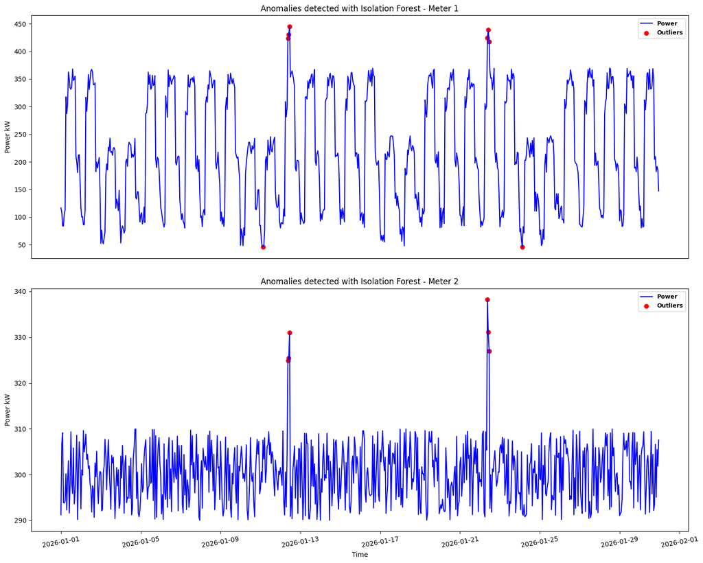

```python
def tracer_Isol_Forest_subplots(df_list):
    """
    Détection d’anomalies non supervisée (Isolation Forest dans scikit-learn)
    """
    n_meters = len(df_list)
    fig, axes = plt.subplots(n_meters, 1, figsize=(15, 6*n_meters), sharex=True)

    if n_meters == 1:
        axes = [axes]

    for i, (df, meter_id) in enumerate(df_list):
        ax = axes[i]
        df_meter = df[df["meter_id"] == meter_id].copy()

        # prend uniquement les valeurs non nulles de la puissance
        Y = df_meter[["power_kw"]].dropna()

        # 100 arbres aléatoires, 1% de valeurs supposées aberrantes, on veut garder toujours le même résultat (random_state=42)
        model = IsolationForest(n_estimators=100, contamination=0.01, random_state=42)

        # trie les scores, il coupe au seuil correspondant à 1% et les pires 1% deviennent -1
        model.fit(Y)

        # applique le model aux données. model.predict(Y) retourne : 1 (normal) ou -1 (anomalie)
        df_meter.loc[Y.index, "state"] = model.predict(Y)

        ax.plot(df_meter["timestamp"], df_meter["power_kw"], color="blue", linestyle='-', markersize = "6", label="Power")
        ax.scatter(
            df_meter[df_meter["state"] == -1]["timestamp"],
            df_meter[df_meter["state"] == -1]["power_kw"],
            color="red", s=40, label="Outliers"
        )

        if i == 0: ax.xaxis.set_visible(False)
        ax.legend(prop={'weight': 'bold', 'size': 9})
        ax.set_title(f"Anomalies detected with Isolation Forest - Meter {meter_id}")
        ax.set_xlabel("Time")
        ax.set_ylabel("Power kW")
        ax.tick_params(axis='x', rotation=10)

    plt.tight_layout(h_pad=3)
    plt.show()

    return [df[df["meter_id"] == meter_id].copy() for _, meter_id in df_list]

df1, df2 = tracer_Isol_Forest_subplots([(df, 1), (df, 2)])
```

## 5️⃣ Analyse de la corrélation avec la température (05_temperature_correlation.py)

### 5.1 Simulation de la température extérieure

Dans le même script, une analyse de corrélation entre la température extérieure et la puissance a été réalisée dans un premier temps sans décalage temporel (lag = 0), puis en introduisant un décalage progressif de 1 à 24 heures afin d’identifier le lag optimal. Ce dernier correspond à la corrélation la plus forte (en valeur absolue), généralement proche de -1 en conditions hivernales. Une corrélation négative proche de -1 signifie que plus la température extérieure diminue, plus la consommation augmente, ce qui est attendu pour un bâtiment tertiaire soumis au chauffage. Cela permet d’estimer le temps de réponse thermique du système (inertie thermique).

#### Résultats :

Pour le compteur 1, la corrélation à lag nul est modérée (−0.47), mais elle devient nettement plus forte avec un décalage de 4 heures (−0.83). Cela indique une dépendance significative de la puissance à la température extérieure avec un retard thermique d’environ 4 heures, caractéristique d’un bâtiment présentant avec inertie thermique.

Pour le compteur 2, la corrélation est quasi nulle à lag nul (−0.079) et reste très faible même avec un lag optimal de une heure (−0.081). Cela confirme que la consommation est indépendante de la température extérieure, ce qui est cohérent avec un process industriel fonctionnant à régime constant.

```
Résultats pour le compteur 1 :
La correlation pour 'Lag 0' est : -0.474
La correlation pour 'Optimal Lag de 4h' est : -0.833

Résultats pour le compteur 2 :
La correlation pour 'Lag 0' est : -0.079
La correlation pour 'Optimal Lag de 1h' est : -0.081
```

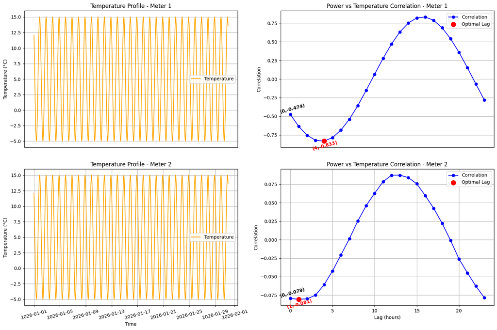

```python
def tracer_temperature_lag_complet(df, meter_ids=[1,2]):
    """
    Simulation de la température exterieure, calcul des lag 24 (de 0 a 23) et détermination du lag optimal
    """
    n_meters = len(meter_ids)
    fig, axes = plt.subplots(n_meters, 2, figsize=(15, 5*n_meters), sharex=False)  # 2 colonnes : profil + corrélation

    if n_meters == 1:
        axes = [axes]

    for i, meter_id in enumerate(meter_ids):
        df_meter = df[df["meter_id"] == meter_id].copy()

        # Température simulée
        n = len(df_meter)
        t = np.arange(n)
        temp_mean = 5
        temp_amp = 10
        phase = -2 * np.pi * 15 / 24
        temp = temp_mean + temp_amp * np.sin(2 * np.pi * t / 24 + phase)
        df_meter["outdoor_temp"] = temp
        df.loc[df_meter.index, "outdoor_temp"] = temp

        # Subplot 1 : profil de température
        ax_profile = axes[i][0]
        if i == 0: ax_profile.xaxis.set_visible(False)
        ax_profile.plot(df_meter["timestamp"], df_meter["outdoor_temp"], color='orange', label="Temperature")
        ax_profile.set_title(f"Temperature Profile - Meter {meter_id}")
        ax_profile.set_xlabel("Time")
        ax_profile.set_ylabel("Temperature (°C)")
        ax_profile.legend()
        ax_profile.grid(True)
        ax_profile.tick_params(axis='x', rotation=15)

        # Corrélation pour lag 0
        corr_lag0 = df_meter["power_kw"].corr(df_meter["outdoor_temp"])
        print(f"\nRésultats pour le compteur {meter_id} :\nLa correlation pour 'Lag 0' est : {corr_lag0:.3f}")


        # Corrélation puissance ↔ température
        corr_lag = [df_meter["power_kw"].corr(df_meter["outdoor_temp"].shift(lag)) for lag in range(24)]
        best_lag = np.argmin(corr_lag)
        best_corr = corr_lag[best_lag]
        print(f"La correlation pour 'Optimal Lag de {best_lag}h' est : {best_corr:.3f}")

        # Subplot 2 : corrélation par lag
        ax_corr = axes[i][1]
        if i == 0: ax_corr.xaxis.set_visible(False)
        ax_corr.plot(range(24), corr_lag, marker='o', color='blue', label="Correlation")
        ax_corr.scatter(best_lag, best_corr, color='red', zorder=10, s=100, label="Optimal Lag")
        ax_corr.annotate(f"({best_lag},{best_corr:.3f})",xy=(best_lag, best_corr),xytext=(2, -20), textcoords='offset points', ha='center', color='red', fontweight='bold', rotation = 15)
        ax_corr.annotate(f"(0,{corr_lag0:.3f})", xy=(0, corr_lag0), xytext=(5, 2), textcoords='offset points', ha='center', color='black', fontweight='bold', rotation = 15)
        ax_corr.set_title(f"Power vs Temperature Correlation - Meter {meter_id}")
        ax_corr.set_xlabel("Lag (hours)")
        ax_corr.set_ylabel("Correlation")
        ax_corr.grid(True)
        ax_corr.legend()

    plt.tight_layout(h_pad=2)
    plt.show()
    return df

df = tracer_temperature_lag_complet(df, meter_ids=[1, 2])
```

### 5.2 Analyse de la corrélation puissance – température

L’analyse de la corrélation entre la puissance et la température extérieure a été réalisée à deux niveaux : d’abord sans décalage temporel (lag = 0), puis en utilisant le lag optimal (lag = 4h). Cette approche permet de comparer la relation directe avec la température et la relation retardée, représentative de l’inertie thermique du système.

#### Résultats :

L’examen des corrélations montre clairement que le comportement des compteurs diffère selon le type de bâtiment ou process. Pour le compteur 1, la corrélation à lag nul est modérée, mais devient très forte avec le lag optimal de 4 heures, ce qui confirme un effet retardé du chauffage : plus la température extérieure baisse, plus la consommation augmente après quelques heures, révélant l’inertie thermique du bâtiment.

Pour le compteur 2, la corrélation reste très très faible, même avec le lag optimal, ce qui indique que la consommation n’est pratiquement pas influencée par la température extérieure, cohérent avec un process industriel à régime constant. Cette analyse confirme que le lag optimal est un indicateur pertinent pour quantifier le temps de réponse thermique des systèmes.

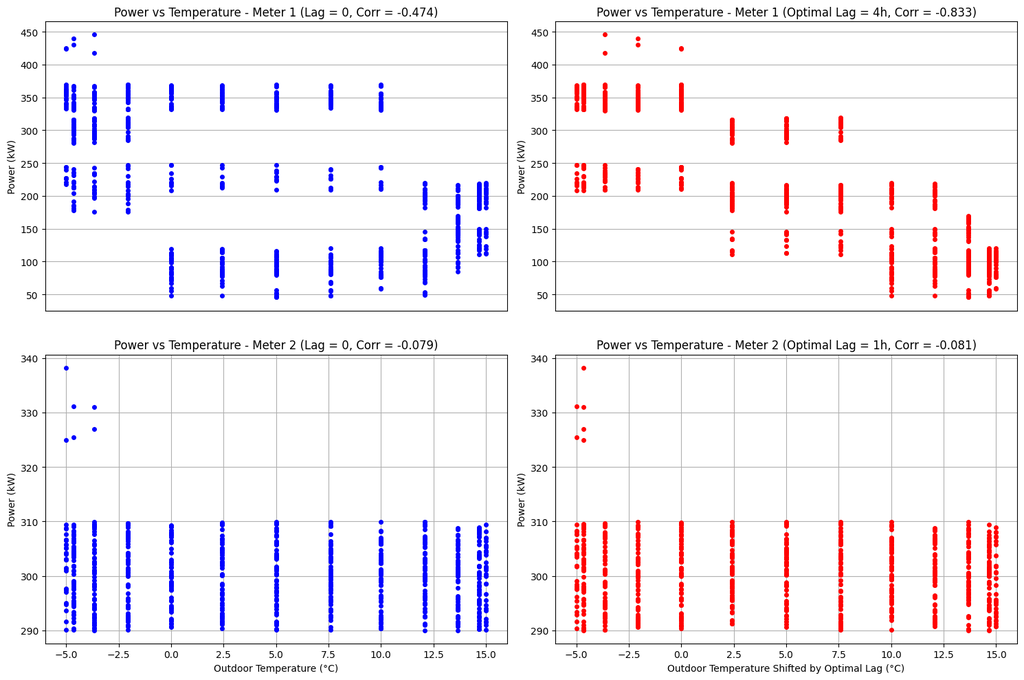

```python
def tracer_puissance_temperature_subplots(df_list):
    """
    fonction pour tracer la puissance vs la température pour lag = 0 puis pour lag optimal
    """
    n_meters = len(df_list)
    fig, axes = plt.subplots(n_meters, 2, figsize=(15, 5*n_meters), sharex=True)

    if n_meters == 1:
        axes = [axes]

    for i, (df, meter_id) in enumerate(df_list):
        df_meter = df[df["meter_id"] == meter_id].copy()

        # Corrélation Pearson lag = 0
        corr = df_meter["power_kw"].corr(df_meter["outdoor_temp"])


        # Scatter plot lag = 0
        ax1 = axes[i][0]
        if i == 0: ax1.xaxis.set_visible(False)
        ax1.plot(df_meter["outdoor_temp"], df_meter["power_kw"], 'o', markersize=4, color='blue')
        ax1.set_xlabel("Outdoor Temperature (°C)")
        ax1.set_ylabel("Power (kW)")
        ax1.set_title(f"Power vs Temperature - Meter {meter_id} (Lag = 0, Corr = {corr:.3f})")
        ax1.grid(True)

        # Corrélation avec lag de 1 à 24h
        corr_lag = [df_meter["power_kw"].corr(df_meter["outdoor_temp"].shift(lag)) for lag in range(24)]
        best_lag = np.argmin(corr_lag)
        best_corr = corr_lag[best_lag]


        # Décalage de la température selon le lag optimal
        temp_shifted = df_meter["outdoor_temp"].shift(best_lag)
        df.loc[df_meter.index, "outdoor_temp_shifted"] = temp_shifted

        # Scatter plot optimal lag
        ax2 = axes[i][1]
        if i == 0: ax2.xaxis.set_visible(False)
        ax2.plot(temp_shifted, df_meter["power_kw"], 'o', markersize=4, color='red')
        ax2.set_xlabel(f"Outdoor Temperature Shifted by Optimal Lag (°C)")
        ax2.set_ylabel("Power (kW)")
        ax2.set_title(f"Power vs Temperature - Meter {meter_id} (Optimal Lag = {best_lag}h, Corr = {best_corr:.3f})")
        ax2.grid(True)

    plt.tight_layout(h_pad=3)
    plt.show()

    return [df[df["meter_id"] == meter_id].copy() for _, meter_id in df_list]

df1, df2 = tracer_puissance_temperature_subplots([(df, 1), (df, 2)])
```

## 6️⃣ Régrission entre puissance et température (06_machine_learning_models.py)

### 6.1 Régrission linéaire

Une régression linéaire a été réalisée pour quantifier la relation entre la puissance et la température extérieure simulée, à **lag nul** (lag = 0) puis avec le **lag optimal** (lag = 4 h). Cette approche permet d’évaluer à la fois l’impact direct de la température sur la consommation et l’effet retardé lié à l’inertie thermique. Cette régression est appliquée aux données du **compteur 1**.

#### Résultats :

| Lag | Coefficients de régression (y = a·x + b) | MAE (kW) | RMSE (kW) | Interprétation |
| --- | --- | --- | --- | --- |
| 0 h | a = −6.9 et b = 254.7 | 77.0 | 91.2 | La puissance augmente d’environ 7 kW pour une baisse de 1 °C. Les erreurs élevées (absolue et quadratique) indiquent que la température seule explique mal la consommation. |
| 4 h (optimal) | a = −12.2 et b = 281.1 | 46.3 | 57.3 | La puissance réagit avec retard à la température. Le décalage de 4 h améliore la modélisation et capture mieux l’effet du chauffage. |

#### Analyse des graphiques :

- **Lag = 0 : relation faiblement structurée**  
  Le nuage de points est très dispersé et la droite de régression représente mal les données. La tendance décroissante existe, mais reste peu marquée.
- **Lag optimal (4 h) : amélioration de la relation**  
  La pente devient plus forte et la tendance décroissante plus nette. Les points sont légèrement mieux alignés, ce qui confirme l’effet de l’inertie thermique.
- **Limite du modèle linéaire**  
  La dispersion reste importante, montrant que la relation réelle n’est pas strictement linéaire et peut être liée à d’autres variables (occupation, équipements, cycles journaliers, température simulée ≠ température réelle)

#### Commentaires :

- Le chauffage réagit à la température extérieure avec un retard d’environ 4 heures, caractéristique de l’inertie thermique du bâtiment.
- La température seule ne suffit pas à expliquer la consommation, ce qui explique les erreurs encore élevées.
- Les résultats du compteur 2 ne sont pas présentés ici car sa puissance est quasi constante (≈ 300 kW) et indépendante de la température.
- Les limites du modèle linéaire justifient l’utilisation d’un modèle plus flexible comme la Random Forest.

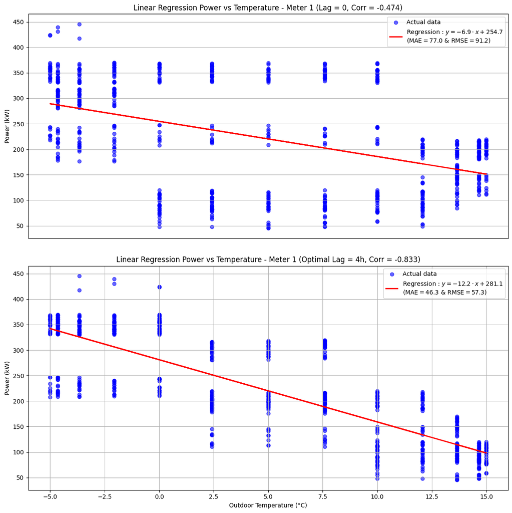

```python
def plot_regression_meter_subplot(df, meter_id):
    """
    Régrission linéaire entre puissance et température (juste pour compteur 1)
    """
    df_meter = df[df['meter_id'] == meter_id].copy()

    fig, axes = plt.subplots(2, 1, figsize=(12,12), sharex=True)

    for i, use_shifted in enumerate([False, True]):
        ax = axes[i]

        # Choix de la colonne température
        temp_col = 'outdoor_temp_shifted' if use_shifted else 'outdoor_temp'

        # Supprimer les lignes avec NaN
        df_temp = df_meter.dropna(subset=[temp_col, 'power_kw'])

        x = df_temp[temp_col].values
        y = df_temp['power_kw'].values

        # Calcul des coefficients
        coef = np.round(np.polyfit(x, y, 1),1)
        y_pred = coef[0]*x + coef[1]

        # métriques
        mae = mean_absolute_error(y, y_pred)                 # Erreur absolue moyenne: MAE=∑ ∣y − y_pred|/n; en moyenne le modèle se trompe de .. kW
        rmse = np.sqrt(mean_squared_error(y, y_pred))        # Erreur quadratique moyenne :pénalise beaucoup plus les grosses erreurs et utile pour détecter les outliers

        # Calcul du corr_lag0 et best_corr pour les mettre dans le titre
        corr_lag = [df_meter["power_kw"].corr(df_meter["outdoor_temp"].shift(lag)) for lag in range(24)]
        corr_lag0 = corr_lag[0]
        best_lag = np.argmin(corr_lag)
        best_corr = corr_lag[best_lag]

        # affichage avec indication si température décalée
        title = f"Meter {meter_id} ({f'Optimal Lag = {best_lag}h, Corr = {best_corr:.3f}' if use_shifted else f'Lag = 0, Corr = {corr_lag0:.3f}'})"

        # Plot
        ax.scatter(x, y, alpha=0.6, label='Actual data', color='blue')
        if i == 0: ax.xaxis.set_visible(False)
        ax.plot(x, y_pred, color='red', linewidth=2, label="Regression : " rf"$y = {coef[0]} \cdot x + {coef[1]}$" + "\n" + rf"($\mathrm{{MAE}}={mae:.1f}\ &\ \mathrm{{RMSE}}={rmse:.1f}$)")
        ax.set_xlabel('Outdoor Temperature (°C)')
        ax.set_ylabel('Power (kW)')
        ax.set_title(f'Linear Regression Power vs Temperature - {title}')
        ax.legend()
        ax.grid(True)

    plt.tight_layout(h_pad=3)
    plt.show()

    return

plot_regression_meter_subplot(df, 1)
```

### 6.2 Régression non linéaire avec Random Forest

La **Random Forest** est un algorithme de **Machine Learning** basé sur un ensemble d’arbres de décision. Contrairement à la régression linéaire, elle permet de modéliser des relations non linéaires entre la température et la puissance, tout en étant moins sensible aux valeurs aberrantes. Ce modèle est appliqué aux données du compteur 1.

#### Résultats :

| Lag | MAE (kW) | RMSE (kW) |
| --- | --- | --- |
| 0 h | 71.1 | 87.0 |
| 4 h (optimal) | 44.1 | 53.0 |

#### Commentaires :

- L’introduction du lag optimal améliore significativement les performances du modèle, cela confirme l’importance de l’inertie thermique dans la modélisation.
- La Random Forest réduit les erreurs par rapport à la régression linéaire, en capturant des relations plus complexes.

#### Analyse des courbes :

- **Comportement en paliers (non linéarité)**  
  Le modèle met en évidence des relations en paliers, correspondant à des changements de régime du système de chauffage.
- **Lag = 0 : relation bruitée**  
  La tendance est visible mais peu structurée, confirmant que la température instantanée ne suffit pas à expliquer la consommation.
- **Lag optimal : relation plus structurée**
  - forte puissance à basse température
  - diminution progressive lorsque la température augmente
  - transitions correspondant à des changements de fonctionnement du système
- **Interprétation physique**  
  Le modèle reproduit correctement le comportement d’un bâtiment chauffé : consommation élevée par temps froid et réduction du chauffage lorsque la température augmente, avec un effet retardé.

#### Conclusion :

La Random Forest améliore significativement la modélisation de la relation puissance–température, notamment en intégrant l’effet du lag. Elle permet de capturer des comportements non linéaires et des changements de régime plus réalistes. Toutefois, l’ajout de variables explicatives supplémentaires serait nécessaire pour améliorer encore la précision du modèle.

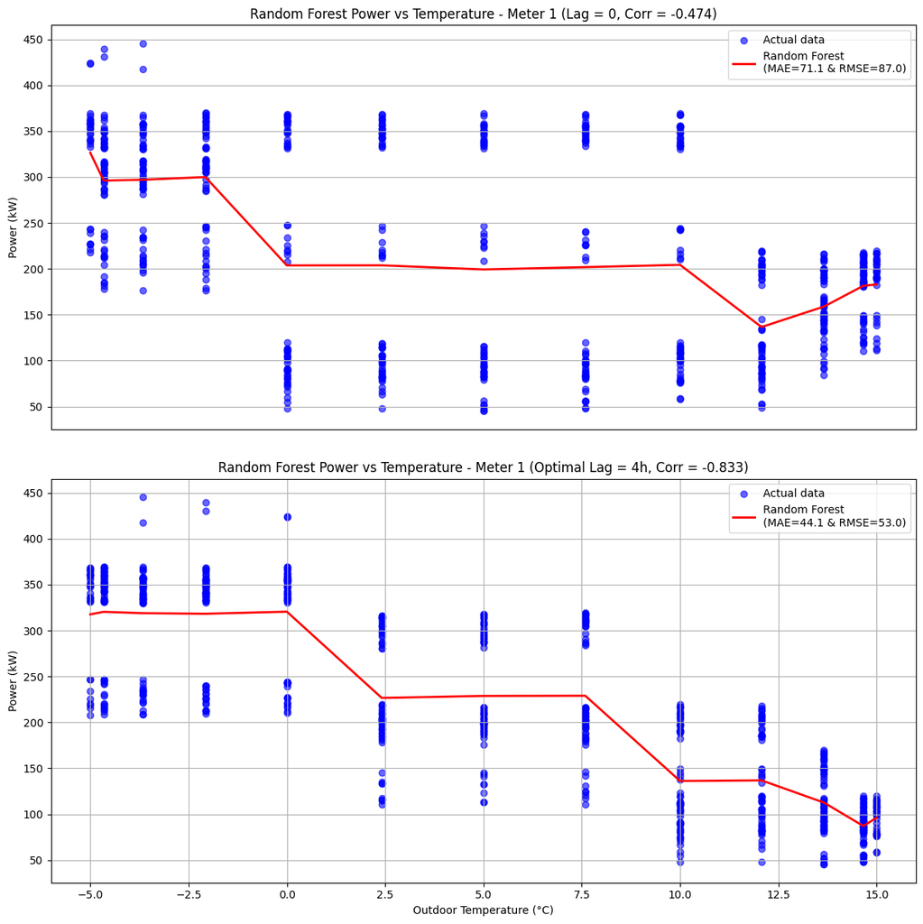

```python
# Régrission non linéaire avec Random Forest entre puissance et température

def plot_Random_Forest_meter_subplot(df, meter_id):
    df_meter = df[df['meter_id'] == meter_id].copy()

    fig, axes = plt.subplots(2, 1, figsize=(12,12), sharex=True)

    for i, use_shifted in enumerate([False, True]):
        ax = axes[i]

        # Choix de la colonne température
        temp_col = 'outdoor_temp_shifted' if use_shifted else 'outdoor_temp'
        X = df_meter[[temp_col]].values
        y = df_meter['power_kw'].values

        # Modèle Random Forest
        model = RandomForestRegressor(n_estimators=100, random_state=42)
        model.fit(X, y)

        # Prédiction
        y_pred = model.predict(X)

        # Métriques
        mae = mean_absolute_error(y, y_pred)
        rmse = np.sqrt(mean_squared_error(y, y_pred))

        # Calcul du corr_lag0 et best_corr pour les mettre dans le titre
        corr_lag = [df_meter["power_kw"].corr(df_meter["outdoor_temp"].shift(lag)) for lag in range(24)]
        corr_lag0 = corr_lag[0]
        best_lag = np.argmin(corr_lag)
        best_corr = corr_lag[best_lag]

        # affichage avec indication si température décalée
        title = f"Meter {meter_id} ({f'Optimal Lag = {best_lag}h, Corr = {best_corr:.3f}' if use_shifted else f'Lag = 0, Corr = {corr_lag0:.3f}'})"

        # Tri pour plot propre
        order = np.argsort(X.flatten())

        # Plot
        ax.scatter(X, y, color="blue", alpha=0.6, label="Actual data")
        if i == 0: ax.xaxis.set_visible(False)
        ax.plot(X.flatten()[order], y_pred[order], color="red", linewidth=2, label=f"Random Forest\n(MAE={mae:.1f} & RMSE={rmse:.1f})")
        ax.set_xlabel("Outdoor Temperature (°C)")
        ax.set_ylabel("Power (kW)")
        ax.set_title(f"Random Forest Power vs Temperature - {title}")
        # ax.plot(X.flatten()[order], y_pred[order], label=f"Random Forest\nMAE={mae:.2f} | RMSE={rmse:.2f}")
        ax.legend()
        ax.grid(True)

    plt.tight_layout(h_pad=3)
    plt.show()

    return

plot_Random_Forest_meter_subplot(df, 1)
```

## 7️⃣ Optimisation DSM (07_demand_side_management.py)

### 7.1 Gestion de la demande énergétique (clipping, shift, reduction)

La gestion de la demande énergétique (DSM) vise à modifier le profil de la consommation afin de réduire les pics, améliorer la stabilité du réseau et optimiser les coûts. Dans cette étude, trois stratégies ont été mises en œuvre : le clipping, le shift et la reduction.

- **Clipping (écrêtage des pics)** : limitation des pics de consommation en plafonnant les valeurs les plus élevées (ici au 95e percentile)
- **Shift (décalage de charge)** : déplacement d’une partie de la consommation (20 %) des heures de pointe (18–20 h) vers les heures creuses (2–4 h)
- **Reduction (réduction)** : diminution de la consommation sur une plage horaire critique (−10 % entre 17 h et 20 h)

#### Analyse des résultats

**Compteur 1** (profil variable)

- Clipping : permet de réduire efficacement les pics et de stabiliser le signal.
- Shift : lissage limité du profil avec impact modéré sur les valeurs extrêmes.
- Reduction : baisse faible des pics sur la plage horaire ciblée.

Le clipping constitue la stratégie la plus adaptée pour gérer les valeurs extrêmes sur ce profil.

**Compteur 2** (profil stable avec pics ponctuels)

- Clipping : efficace pour éliminer les pics isolés.
- Shift : redistribution de l’énergie générant des pics et creux très significatifs, perturbant la stabilité du profil.
- Reduction : accentue les creux sur les périodes réduites, pouvant créer des déséquilibres importants.

Le clipping reste la stratégie la plus robuste, tandis que le shift et la reduction tendent à dégrader la stabilité du signal pour ce profil.

#### Conclusion

- Le clipping permet de maîtriser les extrêmes indépendamment du profil de consommation.
- Le shift et la reduction nécessitent une application prudente, avec un paramétrage précis des plages horaires et des taux de consommation, afin d’éviter toute instabilité supplémentaire.
- La combinaison de ces approches peut optimiser le profil de charge en fonction des caractéristiques du système.

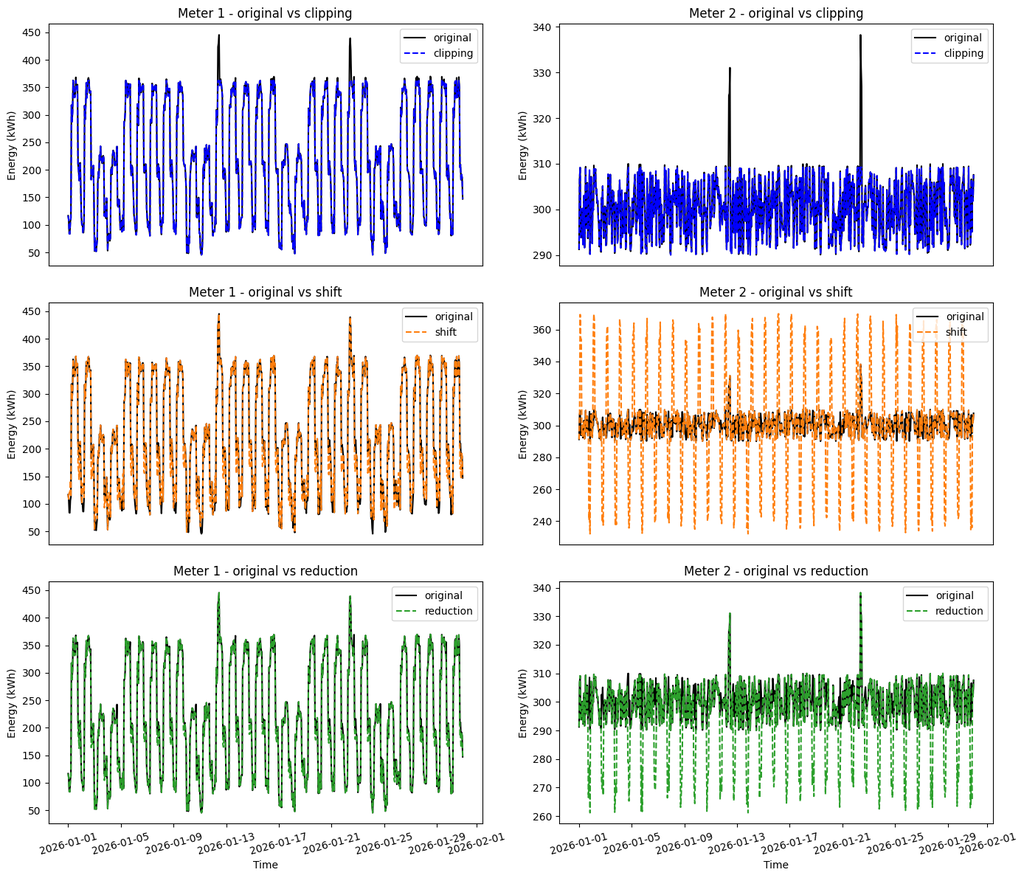

```python
meters = df["meter_id"].unique()
fig, axes = plt.subplots(3, len(meters), figsize=(7*len(meters), 12), sharex=True)

if len(meters) == 1:
    axes = axes.reshape(3,1)  # s'assurer que axes est 2D

for col, meter in enumerate(meters):
    df_meter = df[df["meter_id"] == meter].copy()

    # CLIPPING
    p95 = np.percentile(df_meter["energie_kwh"], 95)                                                        # calculer la valeur de l'énergie en dessous de laquelle se trouvent 95 % des valeurs
    df_meter["energy_clipped"] = np.clip(df_meter["energie_kwh"], None, p95)                                # remplacer les valeurs au dessus de P95 par la P95
    axes[0, col].plot(df_meter["timestamp"], df_meter["energie_kwh"].values, color="black", label="original")
    axes[0, col].plot(df_meter["timestamp"], df_meter["energy_clipped"].values, color="blue", linestyle='--', label="clipping")
    axes[0, col].set_ylabel("Energy (kWh)")
    axes[0, col].set_title(f"Meter {meter} - original vs clipping")
    axes[0, col].xaxis.set_visible(False)
    axes[0, col].legend()

    # SHIFT
    df_meter["energy_shifted"] = df_meter["energie_kwh"].copy()
    mask_peak = df_meter["heure"].between(18,20)                                                            # Définir la plage horaire, mask_peak → heures 18h à 20h (pointe)
    mask_offpeak = df_meter["heure"].between(2,4)                                                           # mask_offpeak → heures 2h à 4h (creux)
    shift = df_meter.loc[mask_peak, "energie_kwh"] * 0.2                                                    # Calculer l'énergie à déplacer (20 %)
    df_meter.loc[mask_peak, "energy_shifted"] -= shift                                                      # diminuer la consommation de -20 % (pointe)
    energy_to_move = shift.sum()                                                                            # somme de l'énergie retirée sur toutes les lignes peak du mois
    n_offpeak = mask_offpeak.sum()                                                                          # nombre total de points mask_offpeak du mois
    df_meter.loc[mask_offpeak, "energy_shifted"] += energy_to_move / n_offpeak                              # ajouter la consommation moyenne (énergie totale reste conservée)
    axes[1, col].plot(df_meter["timestamp"], df_meter["energie_kwh"].values, color="black", label="original")
    axes[1, col].plot(df_meter["timestamp"], df_meter["energy_shifted"].values, color="#ff7f0e", linestyle='--', label="shift")
    axes[1, col].set_ylabel("Energy (kWh)")
    axes[1, col].set_title(f"Meter {meter} - original vs shift")
    axes[1, col].xaxis.set_visible(False)
    axes[1, col].legend()

    # REDUCTION
    df_meter["energy_reduced"] = df_meter["energie_kwh"].copy()
    mask_critical = df_meter["heure"].between(17,20)                                                       # définir la plage houraire de réduction
    df_meter.loc[mask_critical, "energy_reduced"] *= 0.9                                                   # réduire de 10% l'énergie dans la plage houraire mask_critical
    axes[2, col].plot(df_meter["timestamp"], df_meter["energie_kwh"].values, color="black", label="original")
    axes[2, col].plot(df_meter["timestamp"], df_meter["energy_reduced"].values, color="#2ca02c", linestyle='--', label="reduction")
    axes[2, col].set_ylabel("Energy (kWh)")
    axes[2, col].set_title(f"Meter {meter} - original vs reduction")
    axes[2, col].set_xlabel("Time")
    axes[2, col].tick_params(axis='x', rotation=15)
    axes[2, col].legend()

    # Copier les nouvelles colonnes dans le DataFrame principal
    for c in ["energy_clipped", "energy_shifted", "energy_reduced"]:
        df.loc[df["meter_id"] == meter, c] = df_meter[c].values

plt.tight_layout(h_pad=2)
plt.show()
```

### 7.2 Énergie totale, facteur de pointe et économie théorique (Clipping / Shift / Reduction)

#### Définition

- **Énergie totale** : somme de la consommation sur toute la période du mois pour chaque stratégie (original, clipping, shift, reduction).
- **Facteur de pointe** : puissance maximale / puissance moyenne, indicateur de l’intensité des pics.
- **Économie théorique** : différence entre la consommation originale et celle après application d’une stratégie, exprimée ici en kWh et en pourcentage.

Ces métriques permettent de mesurer l’efficacité de chaque stratégie de **Demand Side Management (DSM)**.

#### Résultats

| Compteur | Stratégie | Énergie totale (kWh) | Facteur de pointe | Économie (kWh) | Économie (%) |
| --- | --- | --- | --- | --- | --- |
| 1 | Original | 158398.01 | 2.02 | - | - |
|  | Clipping | 157856.99 | 1.65 | 541.02 | 0.34% |
|  | Shift | 158398.01 | 2.02 | 0 | 0.00% |
|  | Reduction | 155818.60 | 2.06 | 2579.41 | 1.63% |
| 2 | Original | 216282.28 | 1.13 | - | - |
|  | Clipping | 216148.10 | 1.03 | 134.18 | 0.06% |
|  | Shift | 216282.28 | 1.23 | 0 | 0.00% |
|  | Reduction | 212675.32 | 1.15 | 3606.96 | 1.67% |

#### Analyse

- Clipping : réduit fortement le facteur de pointe (pics), impact faible sur l’énergie totale.
- Shift : déplace la consommation, préserve l’énergie totale, pas d'influence sur l’économie mais peut légèrement augmenter le facteur de pointe.
- Reduction : diminue la consommation dans les heures critiques, génère les économies (~1,6–1,7 %) et peut réduire ou légèrement augmenter le facteur de pointe selon le profil.

#### Conclusion

- Pour lisser la demande et limiter les pics : **Clipping** est efficace.
- Pour redistribuer la charge sans changer la consommation globale : **Shift**.
- Pour obtenir des économies réelles d’énergie : **Reduction**.
- Une combinaison des trois stratégies permettrait d’optimiser à la fois la **stabilité des pics** et les **gains énergétiques**.

```python
# calcul Energie totale, facteur de pointe et l'économie théorique pour chaque cas clip/shift/reduce
for meter in df["meter_id"].unique():
    df_meter = df[df["meter_id"] == meter]

    # Énergie totale et test sur la concervation d'energie (totale vs shift), ainsi que reduction (clip and reduce)
    total_original = df_meter["energie_kwh"].sum()
    total_clipped  = df_meter["energy_clipped"].sum()
    total_shifted  = df_meter["energy_shifted"].sum()
    total_reduced  = df_meter["energy_reduced"].sum()

    # Facteur de pointe : puissance maximale / puissance moyenne
    peak_factor_original = df_meter["energie_kwh"].max() / df_meter["energie_kwh"].mean()
    peak_factor_clipped  = df_meter["energy_clipped"].max() / df_meter["energy_clipped"].mean()
    peak_factor_shifted  = df_meter["energy_shifted"].max() / df_meter["energy_shifted"].mean()
    peak_factor_reduced  = df_meter["energy_reduced"].max() / df_meter["energy_reduced"].mean()

    # Économie théorique: énergie originale – énergie après clip/shift/reduce
    saving_clip_kwh   = total_original - total_clipped
    saving_clip_pct   = saving_clip_kwh / total_original * 100
    saving_shift_kwh  = total_original - total_shifted
    saving_shift_pct  = saving_shift_kwh / total_original * 100
    saving_reduce_kwh = total_original - total_reduced
    saving_reduce_pct = saving_reduce_kwh / total_original * 100

    # Afficher les résultats dans un tableau
    df_results = pd.DataFrame({
        "Stratégie": ["Original", "Clipping", "Shift", "Reduction"],
        "Énergie totale (kWh)": [total_original, total_clipped, total_shifted, total_reduced],
        "Facteur de pointe": [peak_factor_original, peak_factor_clipped, peak_factor_shifted, peak_factor_reduced],
        "Économie (kWh)": [0, saving_clip_kwh, saving_shift_kwh, saving_reduce_kwh],
        "Économie (%)": [0, saving_clip_pct, saving_shift_pct, saving_reduce_pct]
     })

    # print(f"\nRésultats pour compteur {meter} :")
    # print(df_results.round(2).to_string(index=False))
```

# Synthèse finale

Le pipeline développé permet de suivre l’ensemble du processus d’analyse énergétique sur 30 jours pour deux compteurs, depuis la génération et le nettoyage des données jusqu’à la modélisation et l’optimisation DSM, avec visualisations intégrées.

## 🧹 Nettoyage des données

La préparation des données a assuré leur cohérence, la création de nouvelles colonnes et le formatage des séries temporelles. Cette étape a été essentielle pour garantir la fiabilité des analyses suivantes et la comparabilité des compteurs.

## 📈 Analyse exploratoire

- Compteur 1 : profil dynamique, structuré avec cycles journaliers marqués, variations fortes et pics artificiels. Sa distribution multimodale et ses heatmaps mettent en évidence des régimes de fonctionnement distincts.
- Compteur 2 : stable, avec consommation quasi constante, faible variabilité et anomalies ponctuelles peu prononcées.

L’analyse visuelle et statistique des distributions et des heatmaps a permis de distinguer les comportements stables des signaux dynamiques et de localiser les anomalies artificielles.

## ⏱️ Analyse des séries temporelles

- Compteur 1 : forte autocorrélation, cycles journaliers réguliers et fluctuations importantes (CV élevé), indiquant un comportement structuré mais non stable.
- Compteur 2 : quasi constant, CV très faible et fluctuations limitées.

L’étude des moyennes glissantes, le Z-robuste et l’IIE est donc nécessaire pour confirmer ces comportements et détecter précisément les anomalies.

## 🚨 Détection d’anomalies

Les méthodes statistiques (Z-score, Z-robuste, IIE) et l’Isolation Forest ont identifié avec précision les anomalies simulées.

- Compteur 1 : dynamique, les fluctuations normales sont ignorées par le Z-robuste.
- Compteur 2 : stable, anomalies ponctuelles clairement identifiées.

L’Isolation Forest s’est montré performant pour détecter à la fois les pics et les valeurs isolées, indépendamment de la structure des séries.

## 🌡️ Analyse de la température

- Compteur 1 : fortement influencé par la température avec un lag optimal de 4 h, révélant l’inertie thermique du bâtiment.
- Compteur 2 : insensible à la température, cohérent avec un process industriel à régime constant.

Cette analyse permet d’estimer le temps de réponse thermique et de quantifier l’effet du chauffage sur la consommation.

## 🤖 Modélisation puissance–température

- Régression linéaire : lag optimal améliore la précision, mais limitée par la non-linéarité des relations.
- Random Forest : capture les comportements non linéaires et les paliers de consommation, réduit MAE/RMSE et restitue mieux l’effet retardé du chauffage pour le compteur 1, mais l’intégration de variables explicatives supplémentaires (équipements, cycles journaliers, température réelle) serait nécessaire pour accroître la précision du modèle.

Le compteur 2 ne nécessite pas de modélisation sophistiquée en raison de sa stabilité.

## ⚡ Optimisation énergétique (DSM)

Trois stratégies testées : clipping, shift et reduction.

- Compteur 1 : clipping réduit efficacement les pics, shift a un effet modéré, reduction agit faiblement sur les plages critiques.
- Compteur 2 : clipping efficace, shift et reduction peuvent perturber la stabilité du signal.

Les métriques d’énergie totale, facteur de pointe et économies théoriques confirment :

- Clipping = méthode la plus robuste
- Shift = redistribue la charge sans économie
- Reduction = génère des économies réelles (~1,6–1,7 %)

# Conclusion générale

Le pipeline permet de comprendre la structure et la variabilité des compteurs, de détecter les anomalies, et de quantifier l’impact de la température sur la consommation.  
La combinaison de méthodes statistiques, machine learning et DSM offre une approche complète pour la gestion énergétique.  
Les stratégies de DSM doivent être adaptées selon le profil : dynamique (compteur 1) ou stable (compteur 2), afin d’optimiser la stabilité du signal, le lissage des pics et les économies énergétiques.  
Le pipeline souligne la nécessité de combiner analyse descriptive des données, modélisation prédictive (régressions, Random Forest) et optimisation opérationnelle (DSM : clipping, shift, reduction) pour une gestion énergétique efficace.